# 第6回 分類の判定を、混同行列で評価する（1行ずつ読む版）

# 6. しきい値を動かすと？

## 段5：しきい値

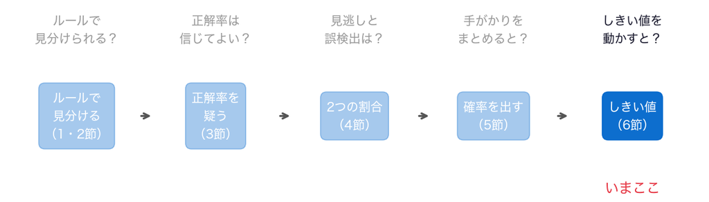

- 問い：確率を切る場所を動かすと、見逃しと誤検出はどう変わるか
- 5節では、確率0.5で切った

## 前の段から

6節 ① 前の段から●

- 0.5で切ると、見逃し83通、誤検出23通
- 見逃しをもっと減らしたいなら、0.5より下で切ればよい
- 確率を切る場所を、しきい値（threshold）と呼ぶ

## しきい値を下げると

6節 ② しきい値を動かす●○○○○○○

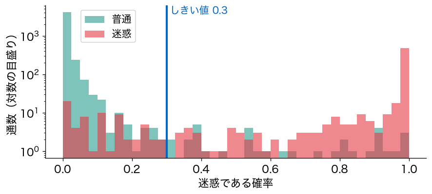

- 線より右を迷惑と判定する。線を左へ動かすと、迷惑をより多く捕まえる

## 表の1マスを取り出す

6節 ② しきい値を動かす●●○○○○○

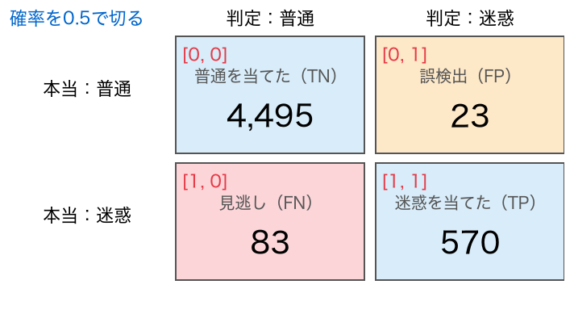

- `m = confusion_matrix(…)`の`m[行, 列]`で、1マスを取り出す（`p[:, 1]`と同じ形）
- 見逃しは`m[1, 0]`（下の行・左の列）、誤検出は`m[0, 1]`

## お手本：しきい値ごとに数える

6節 ② しきい値を動かす●●●○○○○

```python
ts = [0.1, 0.2, 0.3, 0.4, 0.5, 0.6, 0.7, 0.8, 0.9]
fns = []
fps = []
for t in ts:
    pred = (df['確率'] >= t).astype(int)
    m = confusion_matrix(df['迷惑'], pred)
    fns.append(m[1, 0])          # 見逃し
    fps.append(m[0, 1])          # 誤検出
print(pd.DataFrame({'しきい値': ts, '見逃し': fns, '誤検出': fps}))
```

```
 しきい値  見逃し  誤検出
  0.1   33   85
  0.2   55   45
  0.3   66   34
  0.4   76   25
  0.5   83   23
  0.6   92   17
  0.7   99   15
  0.8  118   13
  0.9  143    9
```

## 1行ずつ：しきい値ごとに①

6節 ② しきい値を動かす●●●●○○○

```python
ts = [0.1, 0.2, 0.3, 0.4, 0.5, 0.6, 0.7, 0.8, 0.9]
fns = []
fps = []
for t in ts:
    pred = (df['確率'] >= t).astype(int)
    m = confusion_matrix(df['迷惑'], pred)
    fns.append(m[1, 0])          # 見逃し
    fps.append(m[0, 1])          # 誤検出
print(pd.DataFrame({'しきい値': ts, '見逃し': fns, '誤検出': fps}))
```

- 1行目：しきい値の候補9つのリスト`ts`
- 2・3行目：見逃しと誤検出をためる、空のリストを2つ作る

## 1行ずつ：しきい値ごとに②

6節 ② しきい値を動かす●●●●●○○

```python
ts = [0.1, 0.2, 0.3, 0.4, 0.5, 0.6, 0.7, 0.8, 0.9]
fns = []
fps = []
for t in ts:
    pred = (df['確率'] >= t).astype(int)
    m = confusion_matrix(df['迷惑'], pred)
    fns.append(m[1, 0])          # 見逃し
    fps.append(m[0, 1])          # 誤検出
print(pd.DataFrame({'しきい値': ts, '見逃し': fns, '誤検出': fps}))
```

- 4行目：`t`に0.1、0.2、…を順に入れ、字下げした4行をくり返す
- 5行目：確率が`t`以上なら1の判定を作り、`pred`にしまう
- 6行目：混同行列を作り、`m`にしまう

## 1行ずつ：しきい値ごとに③

6節 ② しきい値を動かす●●●●●●○

```python
ts = [0.1, 0.2, 0.3, 0.4, 0.5, 0.6, 0.7, 0.8, 0.9]
fns = []
fps = []
for t in ts:
    pred = (df['確率'] >= t).astype(int)
    m = confusion_matrix(df['迷惑'], pred)
    fns.append(m[1, 0])          # 見逃し
    fps.append(m[0, 1])          # 誤検出
print(pd.DataFrame({'しきい値': ts, '見逃し': fns, '誤検出': fps}))
```

- 7行目：`m[1, 0]`（見逃し）を、`fns`の後ろに足す
- 8行目：`m[0, 1]`（誤検出）を、`fps`の後ろに足す
- 9行目：3つのリストを列にした表を作り、表示する

## 中身を見る：0.5のときのm

6節 ② しきい値を動かす●●●●●●●

```python
m = confusion_matrix(df['迷惑'], (df['確率'] >= 0.5).astype(int))
print(m)
print(m[1, 0], m[0, 1])
```

```
[[4495   23]
 [  83  570]]
83 23
```

- `m[1, 0]`は下の行・左の列で83（見逃し）、`m[0, 1]`は上の行・右の列で23（誤検出）

## お手本：見逃しと誤検出を描く

6節 ③ 入れ替わる●○○○

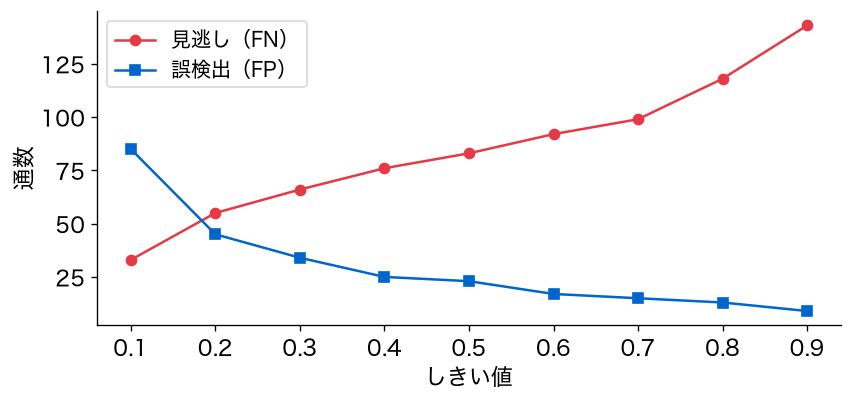

```python
plt.plot(ts, fns, 'o-', label='見逃し（FN）')
plt.plot(ts, fps, 's-', label='誤検出（FP）')
plt.xlabel('しきい値')
plt.ylabel('通数')
plt.legend()
plt.show()
```

## 1行ずつ：2本の線を描く

6節 ③ 入れ替わる●●○○

```python
plt.plot(ts, fns, 'o-', label='見逃し（FN）')
plt.plot(ts, fps, 's-', label='誤検出（FP）')
plt.xlabel('しきい値')
plt.ylabel('通数')
plt.legend()
plt.show()
```

- 1行目：横にしきい値、縦に見逃しの線を描く。`'o-'`は丸い点を線でつなぐ
- 2行目：誤検出の線。`'s-'`は四角い点
- 3〜6行目：軸の名前と凡例を付けて、表示する

## 片方を減らすと、片方が増える

6節 ③ 入れ替わる●●●○

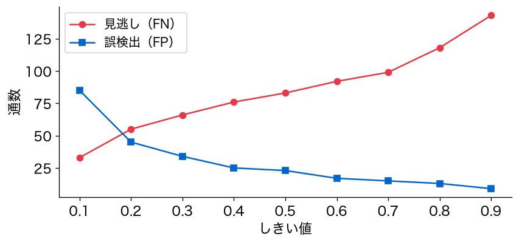

- しきい値0.1では、見逃し33・誤検出85。0.9では、見逃し143・誤検出9
- 2本の線は、逆向きに動く

## 重要：しきい値で入れ替わる

6節 ③ 入れ替わる●●●●

しきい値を下げると見逃しが減って誤検出が増え、上げるとその逆になる。どこで切るかで、同じ式の評価が変わる。

## 全部のしきい値を1枚に

6節 ④ ROC曲線●○○○○○○○

$$\text{誤検出率} = \frac{FP}{FP + TN}$$

- 誤検出率：普通の通のうち、迷惑と判定してしまった割合
- 横に誤検出率、縦に再現率をとり、しきい値ごとに点を打つ

## お手本：ROC曲線を描く

6節 ④ ROC曲線●●○○○○○○

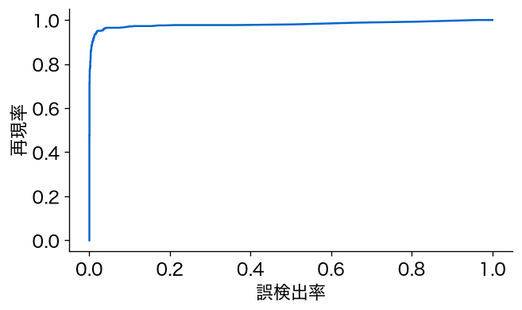

```python
from sklearn.metrics import roc_curve
fpr, tpr, th = roc_curve(df['迷惑'], df['確率'])
plt.plot(fpr, tpr)
plt.xlabel('誤検出率')
plt.ylabel('再現率')
plt.show()
```

## 1行ずつ：ROC曲線を描く①

6節 ④ ROC曲線●●●○○○○○

```python
from sklearn.metrics import roc_curve
fpr, tpr, th = roc_curve(df['迷惑'], df['確率'])
plt.plot(fpr, tpr)
plt.xlabel('誤検出率')
plt.ylabel('再現率')
plt.show()
```

- 1行目：ROC曲線の道具`roc_curve`を呼び出す
- 2行目：本当の答えと確率を渡すと、3つが返る
- 誤検出率の並び`fpr`、再現率の並び`tpr`、しきい値の並び`th`

## 1行ずつ：ROC曲線を描く②

6節 ④ ROC曲線●●●●○○○○

```python
from sklearn.metrics import roc_curve
fpr, tpr, th = roc_curve(df['迷惑'], df['確率'])
plt.plot(fpr, tpr)
plt.xlabel('誤検出率')
plt.ylabel('再現率')
plt.show()
```

- 3行目：誤検出率を横、再現率を縦にして、点を線で結ぶ
- 4〜6行目：軸の名前を付けて、図を表示する

## roc_curveがしていること

6節 ④ ROC曲線●●●●●○○○

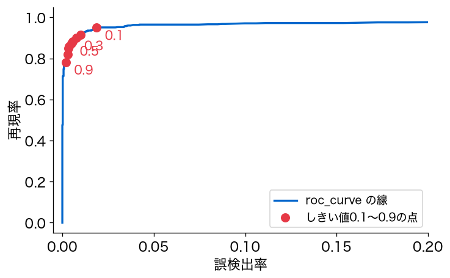

- しきい値を少しずつ下げ、そのたびに誤検出率と再現率を出して並べる
- 上の表の9つのしきい値の点も、この線の上に乗る（横軸は0.2まで）

## 中身を見る：3つの並びの長さ

6節 ④ ROC曲線●●●●●●○○

```python
print(len(fpr), len(tpr), len(th))
```

```
276 276 276
```

- しきい値を276通り試し、そのたびに誤検出率と再現率を出した

## 名前：ROC曲線

6節 ④ ROC曲線●●●●●●●○

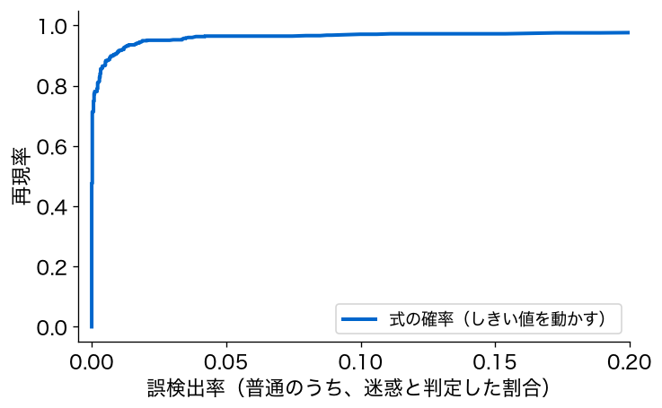

- しきい値を動かしてできる線を、ROC曲線と呼ぶ。左上に近いほど良い

## ルールは、線の下

6節 ④ ROC曲線●●●●●●●●

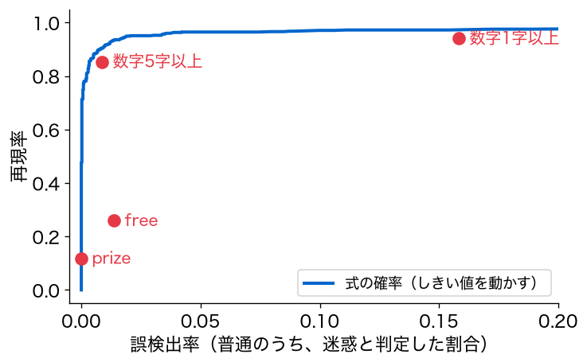

- 赤い点は、これまでのルール。どれも、式の線より下（右）にある
- 同じ誤検出率なら、式のほうが多くの迷惑を捕まえる

## 名前：AUC

6節 ⑤ AUC●○○○

- ROC曲線の下の面積を、AUC（area under the curve）と呼ぶ
- 1に近いほど、迷惑と普通を確率でよく分けている。でたらめなら0.5
- しきい値を決めなくても出せる、確率の付き方そのものの良さ

## お手本：AUCを出す

6節 ⑤ AUC●●○○

```python
from sklearn.metrics import roc_auc_score
print(round(roc_auc_score(df['迷惑'], df['確率']), 3))
```

```
0.981
```

- 本当の答えと確率を渡すと、AUCが返る。しきい値は渡さない

## 1行ずつ：AUCを出す

6節 ⑤ AUC●●●○

```python
from sklearn.metrics import roc_auc_score
print(round(roc_auc_score(df['迷惑'], df['確率']), 3))
```

- 1行目：AUCの道具`roc_auc_score`を呼び出す
- 2行目：本当の答えと確率を渡すと、AUCが返る。しきい値は渡さない

## roc_auc_scoreがしていること

6節 ⑤ AUC●●●●

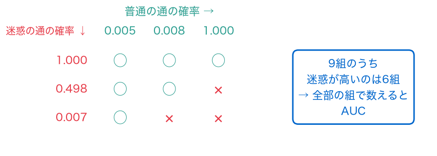

- 迷惑1通と普通1通の組を作り、迷惑のほうが確率の高い組を数える
- 迷惑653通と普通4,518通のすべての組のうち、0.981の割合で迷惑が高い

## お手本：LDAでも確率を出す

6節 ⑥ LDA●○○○○

```python
from sklearn.discriminant_analysis import LinearDiscriminantAnalysis
p = cross_val_predict(LinearDiscriminantAnalysis(), df[cols],
                      df['迷惑'], cv=5, method='predict_proba')
df['判定_lda'] = (p[:, 1] >= 0.5).astype(int)
print(round(accuracy_score(df['迷惑'], df['判定_lda']), 3))
print(confusion_matrix(df['迷惑'], df['判定_lda']))
```

```
0.973
[[4510    8]
 [ 132  521]]
```

- 線形判別分析（LDA）も、確率を出せる。`LogisticRegression()`を替えるだけ

## 1行ずつ：LDA

6節 ⑥ LDA●●○○○

```python
from sklearn.discriminant_analysis import LinearDiscriminantAnalysis
p = cross_val_predict(LinearDiscriminantAnalysis(), df[cols],
                      df['迷惑'], cv=5, method='predict_proba')
df['判定_lda'] = (p[:, 1] >= 0.5).astype(int)
print(round(accuracy_score(df['迷惑'], df['判定_lda']), 3))
print(confusion_matrix(df['迷惑'], df['判定_lda']))
```

- 1行目：LDAの道具`LinearDiscriminantAnalysis`を呼び出す
- 2・3行目：5節の確率のお手本と同じ形。式の作り方だけを替えた
- 4行目：0.5で切って、列「判定_lda」にしまう。5・6行目：正解率と混同行列を表示する

## 正解率は同じ、見逃しは違う

6節 ⑥ LDA●●●○○

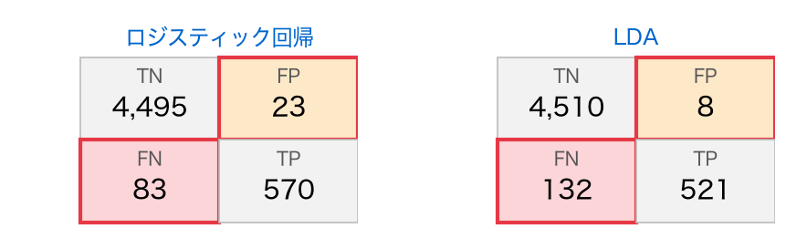

```
ロジスティック回帰  正解率 0.98  AUC 0.981
LDA                 正解率 0.973  AUC 0.981
```

- 正解率は0.98と0.973、AUCはどちらも0.981。1つの数では、ほとんど差がない
- 4つのマスで見ると、見逃しは83通と132通、誤検出は23通と8通

## 1つの数では見えない差

6節 ⑥ LDA●●●●○

- 正解率もAUCも、4つのマスを1つの数にまとめた数。どちらの誤りで外したかが消える
- LDAは見逃しが多く、誤検出が少ない。大事な連絡を失う誤検出のほうが致命的なら、LDAを選ぶこともある
- だから、式どうしを比べるときも、混同行列を並べる（3節と同じ）

## なぜ見逃しが増える？

6節 ⑥ LDA●●●●●

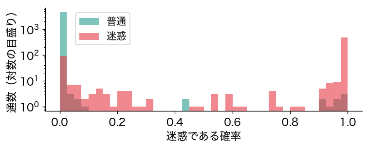

```
0か1の近く  ロジスティック回帰 0.777  LDA 0.978
LDAを0.1で切ると  見逃し 106  誤検出 10
```

- LDAの確率は、0か1の近くに偏る。0.1まで下げても、見逃しは106通
- LDAが悪いのではない。どこで切るのがよいかが、式ごとに違う
- 違いが出たのは、2つのモデルの仮定が違うから。いつもLDAが見逃しを多くする、とは言えない

## しきい値を下げても、残る見逃し

6節 ⑦ 残る見逃し●○○○

- 0.1まで下げても、見逃しは33通残る
- 迷惑なのに、確率がとても小さい通がある。どんなメッセージか

## お手本：見逃した迷惑を読む

6節 ⑦ 残る見逃し●●○○

```python
spam_df = df[df['迷惑'] == 1]
low = spam_df[spam_df['確率'] < 0.05]
print(len(low))
low['本文'].head()
```

```
24
```

```
68     Did you hear about the new "Divorce Barbie"?...
739    Do you realize that in about 40 years, we'll...
740    You have an important customer service annou...
850    Hello. We need some posh birds and chaps to ...
862    Reminder: You have not downloaded the conten...
Name: 本文, dtype: object
```

- 迷惑なのに、確率が0.05より小さい通が24通

## 1行ずつ：見逃した迷惑を読む

6節 ⑦ 残る見逃し●●●○

```python
spam_df = df[df['迷惑'] == 1]
low = spam_df[spam_df['確率'] < 0.05]
print(len(low))
low['本文'].head()
```

- 1行目：迷惑の行だけを取り出し、`spam_df`にしまう
- 2行目：その中から、確率が0.05より小さい行を取り出し、`low`にしまう
- 3行目：`low`の通数を表示する。4行目：本文の先頭5通を表示する

## 普通の会話に見える迷惑

6節 ⑦ 残る見逃し●●●●

- 冗談や誘い、お知らせの形で、数字も15語も出てこない
- 16本の手がかりでは、確率が上がらない。しきい値では救えない
- 捕まえるには、別の手がかりが要る

## TODO⑤：しきい値を替える

6節 ⑧ しきい値を替える●

```python
# TODO: 0.5 を 0.3 に替えて実行する
t = 0.5
df['判定_x'] = (df['確率'] >= t).astype(int)
print(confusion_matrix(df['迷惑'], df['判定_x']))
print(round(recall_score(df['迷惑'], df['判定_x']), 3))
print(round(precision_score(df['迷惑'], df['判定_x']), 3))
```

- 予想：0.3で切ると、見逃し（83）と誤検出（23）は、それぞれどう変わる？

## ここまでで分かったこと

6節 ⑨ 分かったこと●

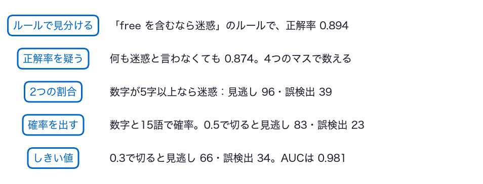

- 5つの段がそろい、今日の問いに答えられる

## ノートへ：6節

6節 10 ノートへ●

- 6節のセルを上から実行し、スライドと同じ数が出るか確かめる
- TODO⑤：予想を書く → `0.5`を`0.3`に替えて実行 → 予想と比べる

動画の人は、ここで一時停止。

## 答え合わせ：TODO⑤

6節 11 答え合わせ●○

```
確率（0.5） [[4495, 23], [83, 570]] (0.873, 0.961)
確率（0.3） [[4484, 34], [66, 587]] (0.899, 0.945)
```

- 0.3で切ると、見逃しは66通に減り、誤検出は34通に増えた
- 再現率が上がり、適合率が下がった

## 式の強みは、選べること

6節 11 答え合わせ●●

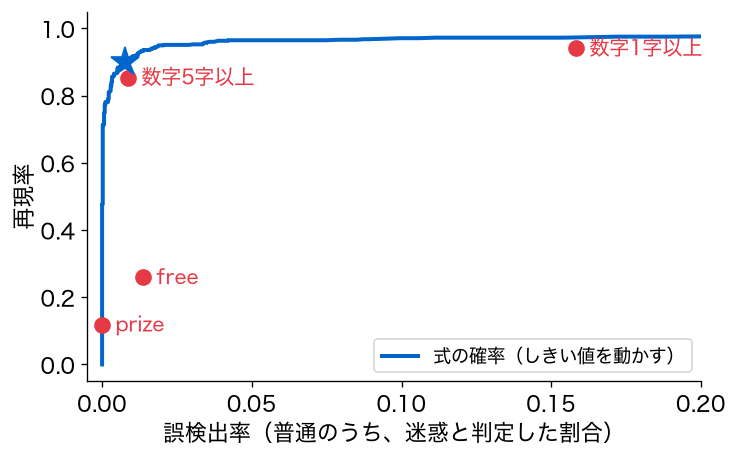

- ★が0.3で切った点。0.5より、見逃しの少ない側
- 式は、しきい値で、見逃しと誤検出の釣り合いを選べる

## 答え：4つのマスで評価する

6節 12 答え●

- 数字と15語で迷惑である確率を出し、0.5で切ると、迷惑653通のうち570通を捕まえる
- そのとき、普通4,518通のうち23通を、誤って迷惑と判定する
- 評価は正解率ではなく、混同行列の見逃しと誤検出で行う。しきい値で釣り合いを選ぶ

## まだ言えないこと

6節 13 まだ言えないこと●

- どこで切るべきか：見逃しと誤検出の重さから、しきい値をどう決めるか
- 手がかりの外：数字も決まり文句もない迷惑を、どう捕まえるか
- 確率は信じてよいか：確率0.3と言われた通は、本当に3割が迷惑か

# まとめ

## 今日の道筋を振り返る

⑨ 振り返る●○○○

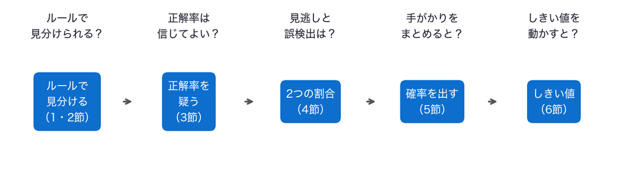

- 5つの段で、ルールで見分け、正解率を疑い、4つのマスと2つの割合で評価し、確率のしきい値を動かした

## 今日持ち帰る1文

⑨ 振り返る●●○○

迷惑メッセージが少ないと、何も見分けなくても正解率は高くなる。混同行列の4つのマスを数え、見逃しと誤検出を分けて評価する。ロジスティック回帰で迷惑である確率を出すと、どこで切るか（しきい値）で、見逃しと誤検出は入れ替わる。

## 今日の重要概念

⑨ 振り返る●●●○

統計：正解率だけで見ない。混同行列の4つのマスを数え、見逃しと誤検出を分けて評価する。

Python：ifは、条件が成り立つ（True）ときだけ、字下げしたブロックを実行する。elseの下は、成り立たないときに動く。

## 今日の要点

⑨ 振り返る●●●●

- 少ない側を見つけたいとき、正解率は多い側の当たりで決まってしまう
- 再現率は見逃しの少なさ、適合率は誤検出の少なさ。2つは引っ張り合う
- ロジスティック回帰で確率を出し、しきい値で切る。ROC曲線とAUCで、全部のしきい値を見る

## 2択を当てる場面は、あちこちに

10 分類の広がり●○○

- 病気の検査：陽性か陰性か。病気の人は少ない
- クレジットカード：不正な使い方か、普通の使い方か。不正はごく一部
- 工場の検査：不良品か、良品か。不良品はめったに出ない

## どこでも、混同行列で話す

10 分類の広がり●●○

- 病気の検査では、再現率を感度と呼ぶ。見逃しを減らしたい
- 迷惑フィルターでは、大事な連絡を失う誤検出を減らしたい
- 分野で呼び名は違っても、4つのマスと2つの誤りは同じ

## 正解率があてにならないとき

10 分類の広がり●●●

- 不正がごく一部なら、何もしなくても正解率はほぼ1になる
- 見つけたいものが少ないほど、正解率は役に立たなくなる
- まず混同行列を作る。今日の流れは、そのまま別のデータに持っていける

## 課題の出し方

11 このあと●○○

- 今日の重要概念は、統計の混同行列と、Pythonのif
- 2つを1枚ずつ絵にし、2枚をLACSに提出（＝出席。期限なし）
- 手描きの写真でも、描画アプリでもよい。上手でなくてよい

## 次回の問い

11 このあと●●○

- 今日は、しきい値を動かすと、見逃しと誤検出が入れ替わるのを見た
- 見逃しと誤検出の重さから、しきい値をどう決めるか

## このあと：課題へ

11 このあと●●●

- ノートの最後の「課題（提出）」を開く
- 絵を描き終えたら、このあとの「解答」で、絵の例と見比べる

# ここから先は解答

## 課題のあとで見る

- ここから先は、課題の絵を描き終えてから見る
- 絵の例を2つ見せる。上手さではなく、考えが伝わるかを見比べる

## 絵の例：混同行列

- 火災報知器の、4つの場合
- 火事で鳴る（当たり）、火事なのに鳴らない（見逃し）
- 料理の煙で鳴る（誤検出）、何もなくて静か（当たり）

## 絵の例：if

- 駅の自動改札
- 切符があれば（条件がTrue）扉が開く。なければ（else）閉まる
- 1人ずつ、条件で通り道が分かれる

# 発展（任意）

## すべての単語を列にしたら？

- 単語を、すべて列にしたらどうなるか
- `CountVectorizer`は、単語ごとに含むかどうかの列を作る道具
- `make_pipeline`で、列を作る道具とロジスティック回帰をつなぎ、交差検証に渡す

## お手本：すべての単語で確率を出す

```python
from sklearn.feature_extraction.text import CountVectorizer
from sklearn.pipeline import make_pipeline
pipe = make_pipeline(CountVectorizer(binary=True),
                     LogisticRegression())
p = cross_val_predict(pipe, df['本文'], df['迷惑'], cv=5,
                      method='predict_proba')
print(round(roc_auc_score(df['迷惑'], p[:, 1]), 3))
print(confusion_matrix(df['迷惑'], (p[:, 1] >= 0.5).astype(int)))
```

```
0.988
[[4513    5]
 [  95  558]]
```

## 1行ずつ：すべての単語

```python
from sklearn.feature_extraction.text import CountVectorizer
from sklearn.pipeline import make_pipeline
pipe = make_pipeline(CountVectorizer(binary=True),
                     LogisticRegression())
p = cross_val_predict(pipe, df['本文'], df['迷惑'], cv=5,
                      method='predict_proba')
print(round(roc_auc_score(df['迷惑'], p[:, 1]), 3))
print(confusion_matrix(df['迷惑'], (p[:, 1] >= 0.5).astype(int)))
```

- 1・2行目：列を作る道具と、道具をつなぐ道具を呼び出す
- 3・4行目：列を作る道具とロジスティック回帰をつなぎ、`pipe`にしまう
- 5〜8行目：`pipe`を式の作り方として渡し、AUCと混同行列を表示する

## 単語は8,713種類

```
単語の種類 8713  全部の通 5171
```

- 列が8,713本。全部の通（5,171通）より多い
- それでも解けるのは、ロジスティック回帰にリッジと同じペナルティ（第5回）が、はじめから入っているから
- AUCは0.988で、16本の手がかり（0.981）より高い

## おわり

- お疲れさまでした